# Part II - (Factors that determine Bike Trip Duration)

## by (Kommomo Usang)

## Investigation Overview

The goal of this investigation was to ascertain the factors that determine the duration of a trip using the Ford GoBike trip system which contained approximately 184,000 individual rides made in a bike-sharing system covering the greater San Francisco Bay area in the month of February 2019. I achieved this by investigating, analysing, exploring and communicating findings as regards my goal statement.

## Dataset Overview

This dataset contains data associated with approximately 184,000 individual rides made in a bike-sharing system covering the greater San Francisco Bay area in the month of February 2019. The dataset initially contained 183,412 entries with 16 features such as duration_sec, start_station_id, start_station_latitude, start_station_longitude, end_station_id, end_station_latitude, end_station_longitude, bike_id, member_birth_year, start_time, end_time, usertype, bike_share_for_all_trip, member_gender, start_station_name and end_station_name. In the course of my wrangling, i had to extract new columns from the existing ones and remove some columns that were not necessary to my goals. While wrangling, i discovered some data quality issues like incorrect data type, missing values, long column names, and a lot of extraneous columns that required cleaning. At the end of my cleaning process, i had 174,952 entries and 15 columns to work with.

## (Distribution of Duration (mins))

Duration is a discrete variable and has a lot of data points-426, making it difficult to visualize significant information using a standard scaled plot. Transforming duration variable to a log scale makes the distribution clearer while providing significant information. On a log scale, the distribution is right skewed and unimodal with highest frequency at 5mins and peak region between 4 and 10mins. This implies that the fastest trips were completed between 4 and 10mins with 5mins as its highest frequency. Specifically, the number of trips completed in 5 mins are 15,073 trips

[output not shown]

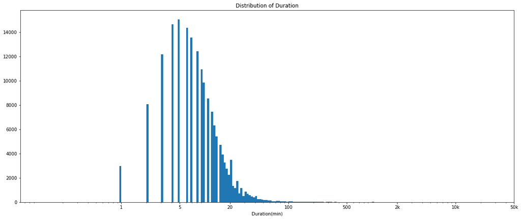

## (Distribution of Age)

Age is a discrete variable and has 75 data points as a result, plotting using a standart scaled plot does not reveal as much information as is needed to get significant insights. Transforming age variable to a log scale makes the distribution clearer while providing significant information. On a log scale, the distribution is right skewed and unimodal with highest frequency at 34 years and peak region between 29 and 45 years of age. Specifically, the number of members at 34 years are 10,214.

```
On a log scale, my plot is still unimodal and right skewed with peak at 34 years of age
```

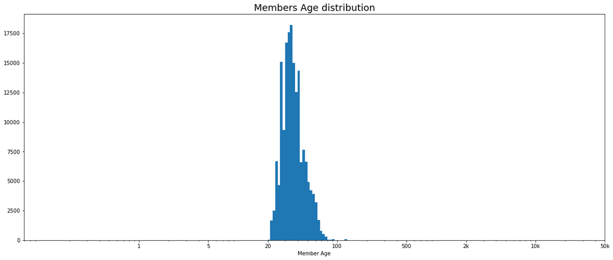

## (Duration and Member Age)

Duration and Age are both discrete variables with enormous data points, i visualized this interaction with both a scatter plot and a heatmap. For this presentation, i will focus on the heatmap

```
My heatmap gives a more informative perspective. The cells with the yellow and bright color have higher counts while the cells with the darker and purple color have lower counts
```

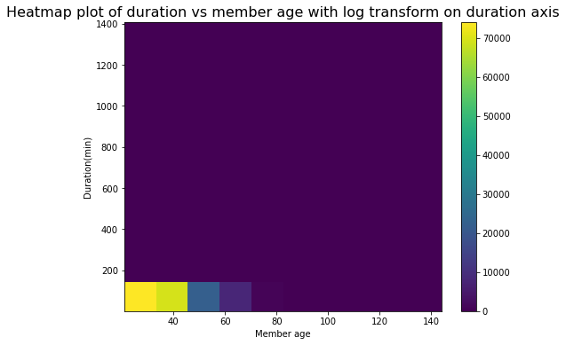

## (Duration and User type)

[output not shown]

[figure not shown]

## (Duration and Member Age by User type)

I used a non positional encoding - color to represent my 3rd variable- usertype. From my plot it is clear that the data points for the subscriber user which is encoded using a thicker shade of blue is consistently lined around the shortest duration which is btw 5-10 mins From my plot it is clear that the data points for the subscriber user is consistently lined around the shortest duration which is btw 5-10 mins. This implies that subscribers between ages of 20 and 45 had the shortest duration of trip, they completed their trips faster. Thus, age and usertype together are a strong combination to predicting how fast a trip can be completed. Specifically 859 subscribers at 34 years completed trips in 6 mins

```
I used a non positional encoding 'color' to represent my 3rd variable- usertype. From my plot it is clear that the data points for the subscriber user which is encoded using a thicker shade of blue is  consistently lined around the shortest duration which is btw 5-10 mins
```

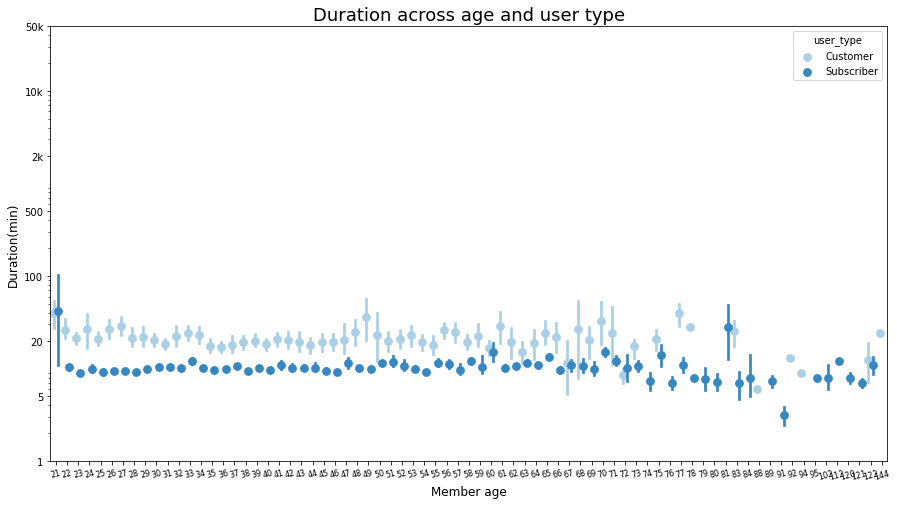

## (Duration and Member Age by Gender)

I used a non positional encoding -color to represent my 3rd variable- gender. From my plot it is clear that the data points for the male gender which is encoded using a light shade of blue is consistently lined around the shortest duration which is btw 5-10 mins. So we can conclude that the Males between the ages of 20 and 45 are more likely to complete their trips in the shortest time. Specifically, 668 Male members at 29 years completed trips in 5 mins

```
I used a non positional encoding 'color' to represent my 3rd variable- gender. From my plot it is clear that the data points for the male gender which is encoded using a light shade of blue is consistently lined around the shortest duration which is btw 5-10 mins
```

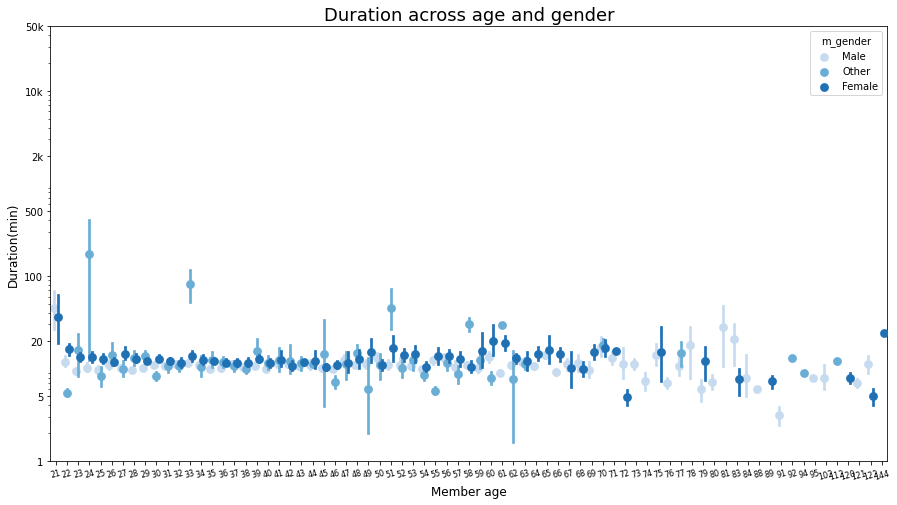